# Module 04b — Screening the corpus, and how much the two models actually agreed

HWC North Africa automated evidence map

2026-08-23

```r
knitr::opts_chunk$set(echo = TRUE, warning = TRUE, message = TRUE, dpi = 300)
suppressPackageStartupMessages({
  library(here); library(dplyr); library(tibble); library(readr); library(ggplot2)
})
source(here::here("R", "config.R"))
```

```r
preds <- readRDS(here::here(DIR_DERIVED, "classification_predictions.rds"))
strata <- readr::read_csv(here::here(DIR_DERIVED, "screening_strata.csv"),
                          show_col_types = FALSE)
agree <- readr::read_csv(here::here(DIR_TABLES, "04b_model_agreement.csv"),
                         show_col_types = FALSE)
contested <- readRDS(here::here(DIR_DERIVED, "contested_set.rds"))
vmet <- readr::read_csv(here::here(DIR_DERIVED, "validation_metrics.csv"),
                        show_col_types = FALSE)
.a <- function(q) agree$value[agree$quantity == q]

n_dedup    <- sum(strata$n)
n_titleonly<- strata$n[strata$stratum == "unscreened_title_only"]
n_failed   <- strata$n[strata$stratum == "unscreened_inference_failed"]
n_screened <- sum(preds$screened %in% TRUE)
n_include  <- strata$n[strata$stratum == "include"]
```

# 1 What this module did

Every deduplicated record with an abstract was classified by both ensemble models, 2 runs each at temperature 0, against the eligibility criteria frozen in Module 01. No sampling, no active learning, no stopping rule: a machine reads all of them, so the recall risk that justifies early termination in human screening does not exist here.

The decision rule is union — include if any model in any run includes — chosen to maximise recall at known cost to precision.

# 2 Record arithmetic

```r
knitr::kable(
  strata |> dplyr::arrange(dplyr::desc(n)) |>
    dplyr::mutate(pct = round(100 * n / n_dedup, 2)),
  caption = sprintf("Disposition of all %s deduplicated records", format(n_dedup, big.mark = ",")))
```

Disposition of all 65,820 deduplicated records

| stratum | n | pct |
| --- | --- | --- |
| exclude | 60411 | 91.78 |
| unscreened_title_only | 4755 | 7.22 |
| include | 550 | 0.84 |
| unscreened_inference_failed | 104 | 0.16 |

Of 65,820 deduplicated records, 60,961 were screened and **550 were included — 0.90% of the screened corpus.** Two strata never reached a decision and must be carried forward as such rather than folded into the excludes.

## 2.1 The title-only stratum is the larger threat to recall

4,755 records (7.2% of the corpus) have no abstract in the ledger and were **not screened at all.**

This was a deliberate choice, and Module 04a is the reason: on the benchmark, restricting to abstract-present records lifted ensemble sensitivity from 0.893 to 1.000. A title alone does not carry enough signal for these models to apply the criteria, and screening on titles would have injected error we could measure but not correct.

The cost is that any relevant study sitting in those 4,755 records is invisible to this map. That is not a rounding error, and Module 07 must not describe a thin cell as an absence without stating it. Records missing an abstract are not missing at random: older records, grey literature, non-English-language venues and smaller regional journals are all over-represented among them — which is the same material a North Africa evidence map is most at risk of under-counting.

# 3 Self-consistency, and why the number is not impressive

```r
sc <- agree |> dplyr::filter(grepl("^self-consistency", quantity))
knitr::kable(sc |> dplyr::mutate(value = sprintf("%.4f", value)),
             caption = "Agreement between run 1 and run 2 of the same model")
```

Agreement between run 1 and run 2 of the same model

| quantity | value |
| --- | --- |
| self-consistency, gemma4:e4b | 1.0000 |
| self-consistency, llama3:latest | 1.0000 |

Both models agreed with themselves on 1.0000 of records — zero flips out of 60,952.

**Read this as a decoding property, not as evidence of stability.** Both runs use temperature 0 and the same seed, and greedy decoding is deterministic: identical inputs must produce identical outputs. A value of 1.00 here was guaranteed before any inference ran, and it measures nothing about robustness. The protocol asks for the number, so it is reported, and it is reported with this caveat every time it appears.

Module 06 measures the thing this was meant to measure, by perturbing temperature between extraction runs so that the two runs can genuinely differ.

# 4 Inter-model agreement

```r
# Counts and coefficients share one column, so format each to its own scale
# rather than letting a single digits= setting print "115.0000".
.fmt <- function(v) ifelse(v == round(v), format(v, big.mark = ",", trim = TRUE),
                           sprintf("%.4f", v))
knitr::kable(
  agree |> dplyr::filter(!grepl("^self-consistency", quantity)) |>
    dplyr::mutate(value = .fmt(value)),
  caption = "Agreement between gemma4:e4b and llama3:latest (union within model)")
```

Agreement between gemma4:e4b and llama3:latest (union within model)

| quantity | value |
| --- | --- |
| records scored by both models | 60,952.0000 |
| raw inter-model agreement | 0.9929 |
| Cohen’s kappa | 0.3433 |
| PABAK | 0.9858 |
| both include | 115.0000 |
| only gemma includes | 338.0000 |
| only llama includes | 96.0000 |
| both exclude | 60,403.0000 |
| contested set size | 434.0000 |
| contested as % of ensemble includes | 78.9000 |

```r
raw_ag  <- .a("raw inter-model agreement")
kap     <- .a("Cohen's kappa")
pab     <- .a("PABAK")
n_both  <- .a("both include")
n_gemma <- .a("only gemma includes")
n_llama <- .a("only llama includes")
n_cont  <- .a("contested set size")
```

Raw agreement is 0.9929, which sounds excellent and is almost meaningless: at a positive rate of 0.90% two models that both said “exclude” to everything would agree 99.10% of the time. The chance-corrected figure is the one to read.

**Cohen’s κ = 0.343** — fair agreement at best, and far below what would be accepted from two human screeners. PABAK is 0.986, but PABAK is high here for the same arithmetic reason raw agreement is: it is dominated by the agreed-exclude cell. The honest summary is that **the two models agree overwhelmingly about what to throw away and disagree substantially about what to keep.**

# 5 The contested set is the finding of this module

```r
pct_cont <- 100 * n_cont / n_include
```

Of the 550 records the ensemble included, only **115 (20.9%) were included by both models.** The other 434 — **78.9% of all includes** — rest on a single model’s vote.

```r
knitr::kable(contested |> dplyr::count(included_by, name = "n_records"),
             caption = "Which model pulled each contested record in")
```

Which model pulled each contested record in

| included_by | n_records |
| --- | --- |
| gemma4:e4b | 338 |
| llama3:latest | 96 |

338 includes come from gemma alone and 96 from llama alone, so the ensemble is substantially gemma’s judgement with a llama-sized minority report attached.

The protocol states the interpretation in advance: *a small contested set is evidence of a well-specified criterion, a large one is a warning about the criteria themselves.* At 79% this is a large contested set, and it is a warning.

```r
cc <- contested |> dplyr::count(cell_country, name = "contested") |>
  dplyr::arrange(dplyr::desc(contested))
knitr::kable(cc, caption = "Contested records by search cell")
```

Contested records by search cell

| cell_country | contested |
| --- | --- |
| EG | 146 |
| TN | 101 |
| MA | 72 |
| REGION | 58 |
| DZ | 38 |
| LY | 19 |

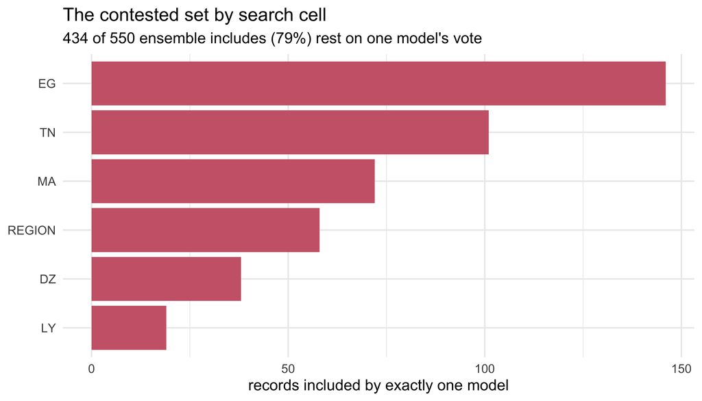

```r
p <- ggplot(cc, aes(x = reorder(cell_country, contested), y = contested)) +
  geom_col(fill = "#CC6677") +
  coord_flip() +
  labs(x = NULL, y = "records included by exactly one model",
       title = "The contested set by search cell",
       subtitle = sprintf("%d of %d ensemble includes (%.0f%%) rest on one model's vote",
                          n_cont, n_include, pct_cont)) +
  theme_minimal(base_size = 11)
print(p)
```

```r
dir.create(here::here(DIR_FIGURES), showWarnings = FALSE, recursive = TRUE)
ggsave(here::here(DIR_FIGURES, "04b_contested_by_cell.png"), p, width = 7, height = 4, dpi = 300)
ggsave(here::here(DIR_FIGURES, "04b_contested_by_cell.svg"), p, width = 7, height = 4)
```

# 6 What the contested set predicted, and what happened next

A large contested set predicts a noisy include set, and that is what Module 06 stage 0 found when it checked where each included study was actually conducted.

```r
geo <- readRDS(here::here(DIR_DERIVED, "geography_verification.rds"))
n_in_scope <- sum(geo$in_scope %in% TRUE)
knitr::kable(geo |> dplyr::count(study_country, sort = TRUE),
             caption = "Verified study location of the included records")
```

Verified study location of the included records

| study_country | n |
| --- | --- |
| multiple North African | 216 |
| other country | 180 |
| not stated | 75 |
| Egypt | 28 |
| Morocco | 23 |
| Tunisia | 16 |
| Algeria | 10 |
| Libya | 2 |

# 7 How much did we miss?

```r
row <- vmet |> dplyr::filter(scope == "abstract_present", polarity == "affirmative")
ci  <- binom.test(row$tp, row$tp + row$fn)$conf.int
```

Deployed sensitivity was 1.000 on the benchmark — but on **13 positive records only.** The exact 95% confidence interval for that estimate runs from 0.753 to 1.000.

So the defensible statement is not “we missed nothing”. It is that the ensemble’s sensitivity is **at least 75% with 95% confidence**, and that the point estimate rests on a very small number of positives. Applied to 550 includes, a sensitivity as low as the interval’s lower bound would imply on the order of 180 relevant records missed among the screened corpus — before counting the 4,755 never screened at all.

Module 07 must quote the interval, not the point estimate.

# 8 Method parameters for the supplement

| parameter | value |
| --- | --- |
| Ensemble | gemma4:e4b + llama3:latest |
| Decision rule | union |
| Runs per (model, record) | 2 |
| Temperature | 0 |
| Seed | 42 |
| Polarity | affirmative (selected on benchmark, not on this corpus) |
| Criteria hash (xxhash64 of the prompt criteria block) | e021124a22ce6e9d |
| Scope | abstract-present records only |
| Cached inference calls | 317,250 |